# Allife_Credit_Card_Customer_Segmentation_Project (UnSupervised_Learning)_Marwan_Kheimi

### Feature Extraction with PCA

Clustering Metrics

Now we will apply PCA to improve clustering. We should be able to see lower inertias and higher silhouette scores after feature extraction.

```python
# apply PCA and display clustering metrics
for y in range(2, 5):
    print("PCA with # of components: ", y)
    pca = PCA(n_components=y)
    data_p = pca.fit_transform(data_imputed)
    for x in range(2, 7):
        alg = KMeans(n_clusters = x, )
        label = alg.fit_predict(data_p)
        print('Silhouette-Score for', x,  'Clusters: ', silhouette_score(data_p, label) , '       Inertia: ',alg.inertia_)
    print()
```

```
PCA with # of components:  2
Silhouette-Score for 2 Clusters:  0.5561616946250978        Inertia:  1486.3226616576057
Silhouette-Score for 3 Clusters:  0.6828641474868153        Inertia:  381.31299388431876
Silhouette-Score for 4 Clusters:  0.4693137547393907        Inertia:  298.1559200374314
Silhouette-Score for 5 Clusters:  0.379659883856397        Inertia:  250.03687548006138
Silhouette-Score for 6 Clusters:  0.38874508044582906        Inertia:  205.54843528623314

PCA with # of components:  3
Silhouette-Score for 2 Clusters:  0.48980753422858286        Inertia:  1697.489636450197
Silhouette-Score for 3 Clusters:  0.6037083469529868        Inertia:  591.578545149154
Silhouette-Score for 4 Clusters:  0.4256459199475647        Inertia:  466.67264806856014
Silhouette-Score for 5 Clusters:  0.34498784436776847        Inertia:  398.63736007306403
Silhouette-Score for 6 Clusters:  0.32140317656570233        Inertia:  356.75340933069197

PCA with # of components:  4
Silhouette-Score for 2 Clusters:  0.44590480512702185        Inertia:  1880.5064880158084
Silhouette-Score for 3 Clusters:  0.5505811761988302        Inertia:  773.7281632647087
Silhouette-Score for 4 Clusters:  0.39114130065686814        Inertia:  624.3157047198661
Silhouette-Score for 5 Clusters:  0.30511524856466443        Inertia:  555.0615396552114
Silhouette-Score for 6 Clusters:  0.27893627021639766        Inertia:  511.1301405406304
```

# Visualization¶

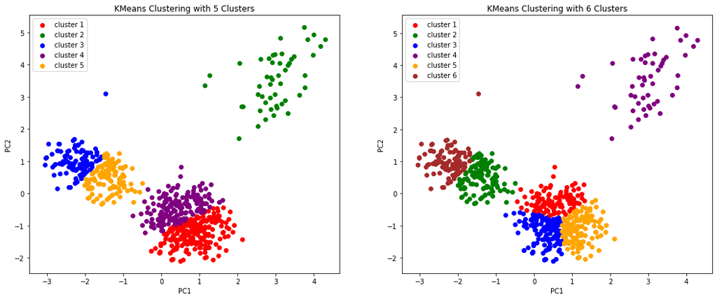

```python
data_p = pd.DataFrame(PCA(n_components = 2).fit_transform(data_imputed))
preds = pd.Series(KMeans(n_clusters = 5,).fit_predict(data_p))
data_p = pd.concat([data_p, preds], axis =1)
data_p.columns = [0,1,'target']

fig = plt.figure(figsize = (18, 7))
colors = ['red', 'green', 'blue', 'purple', 'orange', 'brown']
plt.subplot(121)
plt.scatter(data_p[data_p['target']==0].iloc[:,0], data_p[data_p.target==0].iloc[:,1], c = colors[0], label = 'cluster 1')
plt.scatter(data_p[data_p['target']==1].iloc[:,0], data_p[data_p.target==1].iloc[:,1], c = colors[1], label = 'cluster 2')
plt.scatter(data_p[data_p['target']==2].iloc[:,0], data_p[data_p.target==2].iloc[:,1], c = colors[2], label = 'cluster 3')
plt.scatter(data_p[data_p['target']==3].iloc[:,0], data_p[data_p.target==3].iloc[:,1], c = colors[3], label = 'cluster 4')
plt.scatter(data_p[data_p['target']==4].iloc[:,0], data_p[data_p.target==4].iloc[:,1], c = colors[4], label = 'cluster 5')
plt.legend()
plt.title('KMeans Clustering with 5 Clusters')
plt.xlabel('PC1')
plt.ylabel('PC2')


data_p = pd.DataFrame(PCA(n_components = 2).fit_transform(data_imputed))
preds = pd.Series(KMeans(n_clusters = 6,).fit_predict(data_p))
data_p = pd.concat([data_p, preds], axis =1)
data_p.columns = [0,1,'target']

plt.subplot(122)
plt.scatter(data_p[data_p['target']==0].iloc[:,0], data_p[data_p.target==0].iloc[:,1], c = colors[0], label = 'cluster 1')
plt.scatter(data_p[data_p['target']==1].iloc[:,0], data_p[data_p.target==1].iloc[:,1], c = colors[1], label = 'cluster 2')
plt.scatter(data_p[data_p['target']==2].iloc[:,0], data_p[data_p.target==2].iloc[:,1], c = colors[2], label = 'cluster 3')
plt.scatter(data_p[data_p['target']==3].iloc[:,0], data_p[data_p.target==3].iloc[:,1], c = colors[3], label = 'cluster 4')
plt.scatter(data_p[data_p['target']==4].iloc[:,0], data_p[data_p.target==4].iloc[:,1], c = colors[4], label = 'cluster 5')
plt.scatter(data_p[data_p['target']==5].iloc[:,0], data_p[data_p.target==5].iloc[:,1], c = colors[5], label = 'cluster 6')
plt.legend()
plt.title('KMeans Clustering with 6 Clusters')
plt.xlabel('PC1')
plt.ylabel('PC2')
```

So far, by applying PCA we have made notable improvement to KMeans model. Let's try other clustering models as well!

# Agglomerative Hierarchical Clustering with PCA

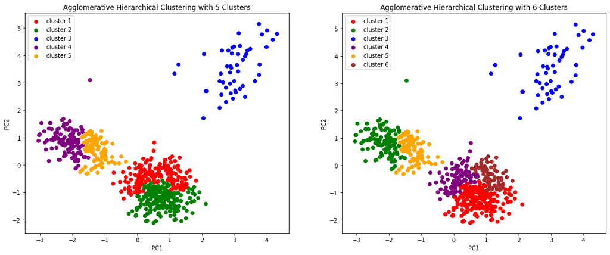

```python
data_p = pd.DataFrame(PCA(n_components = 2).fit_transform(data_imputed))
preds = pd.Series(AgglomerativeClustering(n_clusters = 5,).fit_predict(data_p))
data_p = pd.concat([data_p, preds], axis =1)
data_p.columns = [0,1,'target']

fig = plt.figure(figsize = (18, 7))
colors = ['red', 'green', 'blue', 'purple', 'orange', 'brown']
plt.subplot(121)
plt.scatter(data_p[data_p['target']==0].iloc[:,0], data_p[data_p.target==0].iloc[:,1], c = colors[0], label = 'cluster 1')
plt.scatter(data_p[data_p['target']==1].iloc[:,0], data_p[data_p.target==1].iloc[:,1], c = colors[1], label = 'cluster 2')
plt.scatter(data_p[data_p['target']==2].iloc[:,0], data_p[data_p.target==2].iloc[:,1], c = colors[2], label = 'cluster 3')
plt.scatter(data_p[data_p['target']==3].iloc[:,0], data_p[data_p.target==3].iloc[:,1], c = colors[3], label = 'cluster 4')
plt.scatter(data_p[data_p['target']==4].iloc[:,0], data_p[data_p.target==4].iloc[:,1], c = colors[4], label = 'cluster 5')
plt.legend()
plt.title('Agglomerative Hierarchical Clustering with 5 Clusters')
plt.xlabel('PC1')
plt.ylabel('PC2')


data_p = pd.DataFrame(PCA(n_components = 2).fit_transform(data_imputed))
preds = pd.Series(AgglomerativeClustering(n_clusters = 6,).fit_predict(data_p))
data_p = pd.concat([data_p, preds], axis =1)
data_p.columns = [0,1,'target']

plt.subplot(122)
plt.scatter(data_p[data_p['target']==0].iloc[:,0], data_p[data_p.target==0].iloc[:,1], c = colors[0], label = 'cluster 1')
plt.scatter(data_p[data_p['target']==1].iloc[:,0], data_p[data_p.target==1].iloc[:,1], c = colors[1], label = 'cluster 2')
plt.scatter(data_p[data_p['target']==2].iloc[:,0], data_p[data_p.target==2].iloc[:,1], c = colors[2], label = 'cluster 3')
plt.scatter(data_p[data_p['target']==3].iloc[:,0], data_p[data_p.target==3].iloc[:,1], c = colors[3], label = 'cluster 4')
plt.scatter(data_p[data_p['target']==4].iloc[:,0], data_p[data_p.target==4].iloc[:,1], c = colors[4], label = 'cluster 5')
plt.scatter(data_p[data_p['target']==5].iloc[:,0], data_p[data_p.target==5].iloc[:,1], c = colors[5], label = 'cluster 6')
plt.legend()
plt.title('Agglomerative Hierarchical Clustering with 6 Clusters')
plt.xlabel('PC1')
plt.ylabel('PC2')
```

# Gaussian Mixture Clustering with PCA

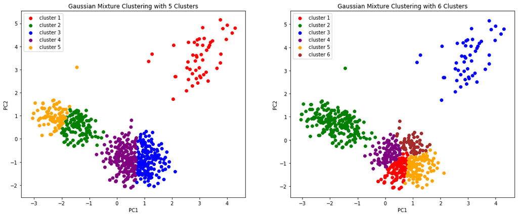

```python
data_p = pd.DataFrame(PCA(n_components = 2).fit_transform(data_imputed))
preds = pd.Series(GaussianMixture(n_components = 5,).fit_predict(data_p))
data_p = pd.concat([data_p, preds], axis =1)
data_p.columns = [0,1,'target']

fig = plt.figure(figsize = (18, 7))
colors = ['red', 'green', 'blue', 'purple', 'orange', 'brown']
plt.subplot(121)
plt.scatter(data_p[data_p['target']==0].iloc[:,0], data_p[data_p.target==0].iloc[:,1], c = colors[0], label = 'cluster 1')
plt.scatter(data_p[data_p['target']==1].iloc[:,0], data_p[data_p.target==1].iloc[:,1], c = colors[1], label = 'cluster 2')
plt.scatter(data_p[data_p['target']==2].iloc[:,0], data_p[data_p.target==2].iloc[:,1], c = colors[2], label = 'cluster 3')
plt.scatter(data_p[data_p['target']==3].iloc[:,0], data_p[data_p.target==3].iloc[:,1], c = colors[3], label = 'cluster 4')
plt.scatter(data_p[data_p['target']==4].iloc[:,0], data_p[data_p.target==4].iloc[:,1], c = colors[4], label = 'cluster 5')
plt.legend()
plt.title('Gaussian Mixture Clustering with 5 Clusters')
plt.xlabel('PC1')
plt.ylabel('PC2')


data_p = pd.DataFrame(PCA(n_components = 2).fit_transform(data_imputed))
preds = pd.Series(GaussianMixture(n_components = 6,).fit_predict(data_p))
data_p = pd.concat([data_p, preds], axis =1)
data_p.columns = [0,1,'target']

plt.subplot(122)
plt.scatter(data_p[data_p['target']==0].iloc[:,0], data_p[data_p.target==0].iloc[:,1], c = colors[0], label = 'cluster 1')
plt.scatter(data_p[data_p['target']==1].iloc[:,0], data_p[data_p.target==1].iloc[:,1], c = colors[1], label = 'cluster 2')
plt.scatter(data_p[data_p['target']==2].iloc[:,0], data_p[data_p.target==2].iloc[:,1], c = colors[2], label = 'cluster 3')
plt.scatter(data_p[data_p['target']==3].iloc[:,0], data_p[data_p.target==3].iloc[:,1], c = colors[3], label = 'cluster 4')
plt.scatter(data_p[data_p['target']==4].iloc[:,0], data_p[data_p.target==4].iloc[:,1], c = colors[4], label = 'cluster 5')
plt.scatter(data_p[data_p['target']==5].iloc[:,0], data_p[data_p.target==5].iloc[:,1], c = colors[5], label = 'cluster 6')
plt.legend()
plt.title('Gaussian Mixture Clustering with 6 Clusters')
plt.xlabel('PC1')
plt.ylabel('PC2')
```

# Exploratory Data Analysis

We are picking 6 clusters for this EDA. Let's make a Seaborn pairplot with selected/best columns to show how the clusters are segmenting the samples:

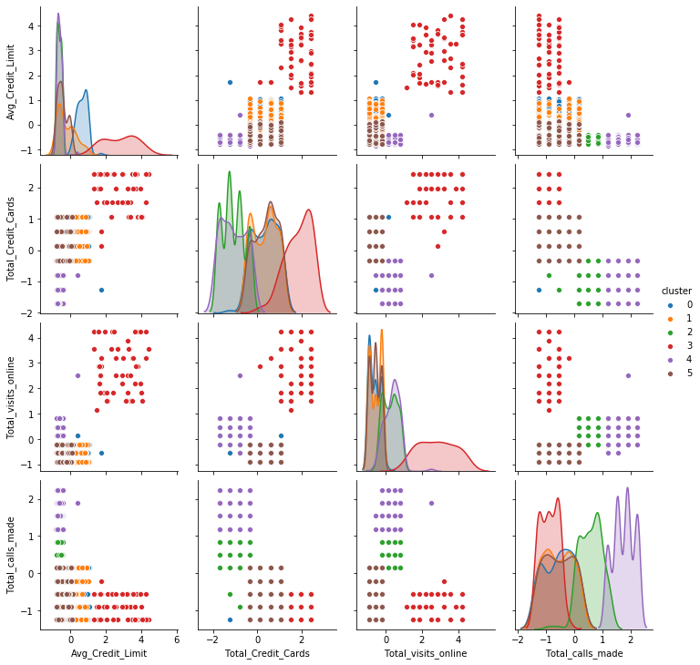

```python
# select best columns
best_cols = ["Avg_Credit_Limit", "Total_Credit_Cards", "Total_visits_online", "Total_calls_made"]

# apply KMeans clustering
alg = KMeans(n_clusters = 6)
label = alg.fit_predict(data_imputed)

# create a 'cluster' column
data_imputed['cluster'] = label
best_cols.append('cluster')

# make a Seaborn pairplot
sns.pairplot(data_imputed[best_cols], hue='cluster')
```

```python
data_new.apply(zscore)
```

|  | Avg_Credit_Limit | Total_Credit_Cards | Total_visits_bank | Total_visits_online | Total_calls_made |
| --- | --- | --- | --- | --- | --- |
| 0 | 1.740187 | -1.249225 | -0.860451 | -0.547490 | -1.251537 |
| 1 | 0.410293 | -0.787585 | -1.473731 | 2.520519 | 1.891859 |
| 2 | 0.410293 | 1.058973 | -0.860451 | 0.134290 | 0.145528 |
| 3 | -0.121665 | 0.135694 | -0.860451 | -0.547490 | 0.145528 |
| 4 | 1.740187 | 0.597334 | -1.473731 | 3.202298 | -0.203739 |
| ... | ... | ... | ... | ... | ... |
| 655 | 1.713589 | 2.443892 | -0.860451 | 2.520519 | -1.251537 |
| 656 | 1.314621 | 2.443892 | -0.860451 | 3.543188 | -0.553005 |
| 657 | 2.937092 | 1.520613 | -0.860451 | 2.179629 | -0.902271 |
| 658 | 3.655235 | 2.443892 | -0.860451 | 4.224968 | -1.251537 |
| 659 | 3.522245 | 1.982253 | -1.473731 | 3.202298 | -0.553005 |

660 rows × 5 columns

```python
d_euc = pdist(data.iloc[:,2:7], metric = 'euclidean')
```

```python
# Build the Clusters
clus1 = linkage(d_euc, method = 'average')
```

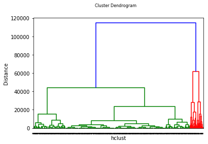

```python
# Display the Clusters in Dendogram
dendrogram(clus1, labels=data["Total_visits_bank"].values.tolist())
plt.xlabel('hclust')
plt.ylabel('Distance')
plt.suptitle('Cluster Dendrogram', fontsize = 8)
```

```python
d_euc2 = pdist(data.iloc[:,2:7], metric = 'euclidean')
print(np.round(squareform(d_euc2).tolist(),3))
```

```
[[0.00000000e+00 5.00000020e+04 5.00000000e+04 ... 4.50000010e+04
  7.20000020e+04 6.70000010e+04]
 [5.00000020e+04 0.00000000e+00 9.53900000e+00 ... 9.50000000e+04
  1.22000001e+05 1.17000000e+05]
 [5.00000000e+04 9.53900000e+00 0.00000000e+00 ... 9.50000000e+04
  1.22000001e+05 1.17000000e+05]
 ...
 [4.50000010e+04 9.50000000e+04 9.50000000e+04 ... 0.00000000e+00
  2.70000010e+04 2.20000000e+04]
 [7.20000020e+04 1.22000001e+05 1.22000001e+05 ... 2.70000010e+04
  0.00000000e+00 5.00000100e+03]
 [6.70000010e+04 1.17000000e+05 1.17000000e+05 ... 2.20000000e+04
  5.00000100e+03 0.00000000e+00]]
```

```python
clus2 = linkage(pdist(data.iloc[:,2:7], metric = 'euclidean'), method = 'average')
distance = clus2[:,2]
distance
```

[output not shown]

[output cut: 110 more lines]

[output not shown]

```python
# Profiling the clusters
data['Clusters'] = cut_tree(clus2,2)
clus_profile = data.iloc[:,2:8].groupby(['Clusters'],as_index=False).mean()
clus_profile
```

|  | Clusters | Avg_Credit_Limit | Total_Credit_Cards | Total_visits_bank | Total_visits_online | Total_calls_made |
| --- | --- | --- | --- | --- | --- | --- |
| 0 | 0 | 140235.294118 | 8.607843 | 0.607843 | 10.705882 | 1.058824 |
| 1 | 1 | 25725.779967 | 4.379310 | 2.553366 | 1.927750 | 3.794745 |

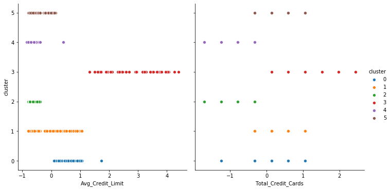

```python
sns.pairplot(data_imputed[best_cols], hue='cluster', x_vars=['Avg_Credit_Limit', 'Total_Credit_Cards'],
            y_vars=['cluster'],
            height=5, aspect=1)
```

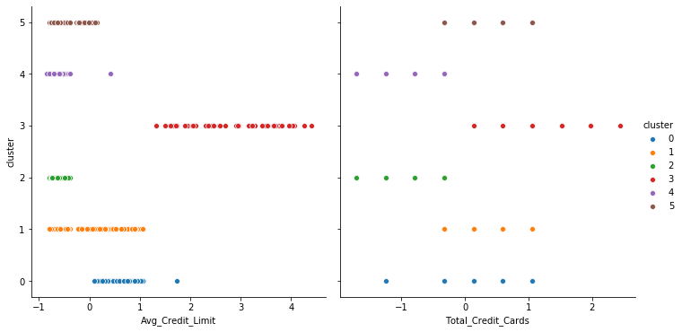

```python
sns.pairplot(data_imputed[best_cols], hue='cluster', x_vars=['Avg_Credit_Limit', 'Total_Credit_Cards'], y_vars=['cluster'],
            height=5, aspect=1)
```

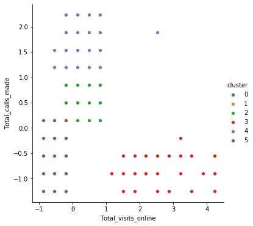

```python
sns.pairplot(data_imputed[best_cols], hue='cluster', x_vars=['Total_visits_online'], y_vars=['Total_calls_made'],
            height=5, aspect=1)
```

Summary and Possible Marketing Strategy

We have learned a lot from this dataset by segmenting the customers into six smaller groups: the Average Joe, the Active Users, the Big Spenders, the Money Borrowers, the High Riskers, and the Wildcards. To conclude this cluster analysis, let's sum up what we have learned and some possible marketing strategies:

```
The Average Joe do not use credit card very much in their daily life. They have healthy finances and low debts. While encouraging these people to use credit cards more is necessary for the company's profit, business ethics and social responsibility should also be considered.

Identify active customers in order to apply proper marketing strategy towards them. These people are the main group that we should focus on.

Some people are just bad at finance management - for example, the Money Borrowers. This should not be taken lightly.

Although we are currently doing a good job at managing the High Riskers by giving them low credit limits, more marketing strategies targeting this group of customers should be considered.
```

Conclusion

In this project, we have performed data preprocessing, feature extraction with PCA, looked at various clustering metrics (inertias, silhouette scores), experimented with various Clustering algorithms (KMeans Clustering, Agglomerative Hierarchical Clustering, Gaussian Mixture Clustering), data visualizations, and business analytics.

This project is also my first try on the business side of Data Science, and how we can use Machine Learning to solve practical, real life issues.